# python_MovingAverage

Hola Ana :)

#### Integrantes:

María Fernanda Gutiérrez

Brenda Aurora Rubio

Rafael Loyola

Carlos Muñoz

En este documento vamos a hacer el cálculo de MA para nuestro proyecto.

## ¿En qué consiste el método de "Promedios Móviles"?

El promedio móvil es un indicador de tendencias que se usan para realizar análisis de datos anteriores con la finalidad de formar una serie de medidas que provengan de diversos subconjuntos de datos, por lo tanto, tienen la capacidad de examinar las medidas de dichos datos que disminuyen o aumentan en un periodo de tiempo.

Estas medidas se pueden clasificar como conductores, ya que utilizan diversos datos anteriores para trazar nuevas líneas de datos. Se manifiestan por medio de señales luego de que la nueva tendencia o los movimientos importantes de datos hayan comenzado.

## Consideraciones

Las series de tiempo horizontales son aquellas gráficas que representan a un proceso que se encuentra estable en el tiempo. La variación que existe se debe únicamente a la variación natural. Cuando se cuenta con este tipo de gráfica se puede emplear el método para realizar los pronósticos de promedio móvil.

Al estar disponible cada nueva observación, se puede calcular una nueva media eliminando el valor más antiguo e incluyendo el más reciente. Entonces, se usa este promedio móvil para pronosticar el siguiente periodo.

## Limitantes

En los promedios móviles solamente es posible llegar a pronosticar un periodo más. Suelen ser simplificaciones reales y no garantizan las variables influyentes en el futuro de los pronósticos que se encuentren incluidos en el modelo de dicho pronóstico.

## 1. Paquetes

```python
import pandas as pd #Leer los datos
```

```python
#pip install sklearn.metrics
from sklearn.metrics import mean_absolute_error
```

```python
import matplotlib.pyplot as ptl #Graficar
```

## 2. Leer datos

```python
datos = pd.read_csv("C:/Users/fergt/OneDrive/Documentos/Fer/8° Semestre/Laboratorio de diseño y optimización de operaciones/Proyecto Huawei/huawei_datos_limpios_completos.csv")
```

```python
datos.head()
```

|  | pdv_id | mes_id | sku_id | ventas_totales | y_ventas_siguiente_mes | ventas_totales_en_tienda_de_cada_mes | ventas_promedio_en_tienda_de_cada_mes | ventas_totales_en_tienda_de_cada_sku | ventas_promedio_en_tienda_de_cada_sku | ventas_totales_1_mes_pasado | ... | ventas_totales_tienda_y_mes_3_pasado | ventas_promedio_tienda_y_mes_del_mes_pasado | ventas_promedio_tienda_y_mes_2_pasado | ventas_promedio_tienda_y_mes_3_pasado | ventas_totales_tienda_y_sku_del_mes_pasado | ventas_totales_tienda_y_sku_2_pasado | ventas_totales_tienda_y_sku_3_pasado | ventas_promedio_tienda_y_sku_del_mes_pasado | ventas_promedio_tienda_y_sku_2_pasado | ventas_promedio_tienda_y_sku_3_pasado |
| --- | --- | --- | --- | --- | --- | --- | --- | --- | --- | --- | --- | --- | --- | --- | --- | --- | --- | --- | --- | --- | --- |
| 0 | 1 | 0 | 1 | 1 | 0 | 29 | 0.852941 | 2096 | 1.103739 | 1 | ... | 29 | 0.852941 | 0.852941 | 0.852941 | 2096 | 2096 | 2096 | 1.103739 | 1.103739 | 1.103739 |
| 1 | 1 | 1 | 1 | 0 | 0 | 29 | 0.852941 | 1892 | 0.996314 | 1 | ... | 29 | 0.852941 | 0.852941 | 0.852941 | 2096 | 2096 | 2096 | 1.103739 | 1.103739 | 1.103739 |
| 2 | 1 | 2 | 1 | 0 | 0 | 30 | 0.882353 | 802 | 0.422328 | 0 | ... | 29 | 0.852941 | 0.852941 | 0.852941 | 1892 | 2096 | 2096 | 0.996314 | 1.103739 | 1.103739 |
| 3 | 1 | 3 | 1 | 0 | 0 | 25 | 0.735294 | 386 | 0.203265 | 0 | ... | 29 | 0.882353 | 0.852941 | 0.852941 | 802 | 1892 | 2096 | 0.422328 | 0.996314 | 1.103739 |
| 4 | 1 | 4 | 1 | 0 | 0 | 21 | 0.617647 | 131 | 0.068984 | 0 | ... | 29 | 0.735294 | 0.882353 | 0.852941 | 386 | 802 | 1892 | 0.203265 | 0.422328 | 0.996314 |

5 rows × 24 columns

```python
datos.shape
```

```
(581094, 24)
```

```python
datos.columns
```

```
Index(['pdv_id', 'mes_id', 'sku_id', 'ventas_totales',
       'y_ventas_siguiente_mes', 'ventas_totales_en_tienda_de_cada_mes',
       'ventas_promedio_en_tienda_de_cada_mes',
       'ventas_totales_en_tienda_de_cada_sku',
       'ventas_promedio_en_tienda_de_cada_sku', 'ventas_totales_1_mes_pasado',
       'ventas_totales_2_meses_pasados', 'ventas_totales_3_meses_pasados',
       'ventas_totales_tienda_y_mes_del_mes_pasado',
       'ventas_totales_tienda_y_mes_2_pasado',
       'ventas_totales_tienda_y_mes_3_pasado',
       'ventas_promedio_tienda_y_mes_del_mes_pasado',
       'ventas_promedio_tienda_y_mes_2_pasado',
       'ventas_promedio_tienda_y_mes_3_pasado',
       'ventas_totales_tienda_y_sku_del_mes_pasado',
       'ventas_totales_tienda_y_sku_2_pasado',
       'ventas_totales_tienda_y_sku_3_pasado',
       'ventas_promedio_tienda_y_sku_del_mes_pasado',
       'ventas_promedio_tienda_y_sku_2_pasado',
       'ventas_promedio_tienda_y_sku_3_pasado'],
      dtype='object')
```

## 3. Formato de datos

```python
datos_ma = datos.drop(['ventas_totales_en_tienda_de_cada_mes',
       'ventas_promedio_en_tienda_de_cada_mes',
       'ventas_totales_en_tienda_de_cada_sku',
       'ventas_promedio_en_tienda_de_cada_sku', 'ventas_totales_1_mes_pasado',
       'ventas_totales_2_meses_pasados', 'ventas_totales_3_meses_pasados',
       'ventas_totales_tienda_y_mes_del_mes_pasado',
       'ventas_totales_tienda_y_mes_2_pasado',
       'ventas_totales_tienda_y_mes_3_pasado',
       'ventas_promedio_tienda_y_mes_del_mes_pasado',
       'ventas_promedio_tienda_y_mes_2_pasado',
       'ventas_promedio_tienda_y_mes_3_pasado',
       'ventas_totales_tienda_y_sku_del_mes_pasado',
       'ventas_totales_tienda_y_sku_2_pasado',
       'ventas_totales_tienda_y_sku_3_pasado',
       'ventas_promedio_tienda_y_sku_del_mes_pasado',
       'ventas_promedio_tienda_y_sku_2_pasado',
       'ventas_promedio_tienda_y_sku_3_pasado'], axis=1)
```

```python
datos_ma.head()
```

|  | pdv_id | mes_id | sku_id | ventas_totales | y_ventas_siguiente_mes |
| --- | --- | --- | --- | --- | --- |
| 0 | 1 | 0 | 1 | 1 | 0 |
| 1 | 1 | 1 | 1 | 0 | 0 |
| 2 | 1 | 2 | 1 | 0 | 0 |
| 3 | 1 | 3 | 1 | 0 | 0 |
| 4 | 1 | 4 | 1 | 0 | 0 |

## 4. Promedios móviles

### 4.1 Pedir lo del mes pasado

```python
datos_ma['m1_pedir_mes_anterior'] = datos_ma['ventas_totales']
```

```python
datos_ma.head()
```

|  | pdv_id | mes_id | sku_id | ventas_totales | y_ventas_siguiente_mes | m1_pedir_mes_anterior |
| --- | --- | --- | --- | --- | --- | --- |
| 0 | 1 | 0 | 1 | 1 | 0 | 1 |
| 1 | 1 | 1 | 1 | 0 | 0 | 0 |
| 2 | 1 | 2 | 1 | 0 | 0 | 0 |
| 3 | 1 | 3 | 1 | 0 | 0 | 0 |
| 4 | 1 | 4 | 1 | 0 | 0 | 0 |

### 4.2 Pedir el promedio de 2 meses anteriores

```python
datos_ma['m2_pedir_2_meses_anteriores'] = datos_ma.groupby(['pdv_id', 'sku_id']).rolling(2)['ventas_totales'].mean().reset_index(drop=True)
```

```python
datos_ma.head()
```

|  | pdv_id | mes_id | sku_id | ventas_totales | y_ventas_siguiente_mes | m1_pedir_mes_anterior | m2_pedir_2_meses_anteriores |
| --- | --- | --- | --- | --- | --- | --- | --- |
| 0 | 1 | 0 | 1 | 1 | 0 | 1 | NaN |
| 1 | 1 | 1 | 1 | 0 | 0 | 0 | 0.5 |
| 2 | 1 | 2 | 1 | 0 | 0 | 0 | 0.0 |
| 3 | 1 | 3 | 1 | 0 | 0 | 0 | 0.0 |
| 4 | 1 | 4 | 1 | 0 | 0 | 0 | 0.0 |

### 4.3 Pedir el promedio de 3 meses anteriores

```python
datos_ma['m3_pedir_3_meses_anteriores'] = datos_ma.groupby(['pdv_id', 'sku_id']).rolling(3)['ventas_totales'].mean().reset_index(drop=True)
```

```python
datos_ma.head()
```

|  | pdv_id | mes_id | sku_id | ventas_totales | y_ventas_siguiente_mes | m1_pedir_mes_anterior | m2_pedir_2_meses_anteriores | m3_pedir_3_meses_anteriores |
| --- | --- | --- | --- | --- | --- | --- | --- | --- |
| 0 | 1 | 0 | 1 | 1 | 0 | 1 | NaN | NaN |
| 1 | 1 | 1 | 1 | 0 | 0 | 0 | 0.5 | NaN |
| 2 | 1 | 2 | 1 | 0 | 0 | 0 | 0.0 | 0.333333 |
| 3 | 1 | 3 | 1 | 0 | 0 | 0 | 0.0 | 0.000000 |
| 4 | 1 | 4 | 1 | 0 | 0 | 0 | 0.0 | 0.000000 |

## 5. Cálculo de errores

### 5.1 Dividir por mes

```python
error_julio = datos_ma[datos_ma.mes_id==0]
error_julio.head()
```

|  | pdv_id | mes_id | sku_id | ventas_totales | y_ventas_siguiente_mes | m1_pedir_mes_anterior | m2_pedir_2_meses_anteriores | m3_pedir_3_meses_anteriores |
| --- | --- | --- | --- | --- | --- | --- | --- | --- |
| 0 | 1 | 0 | 1 | 1 | 0 | 1 | NaN | NaN |
| 9 | 1 | 0 | 2 | 1 | 1 | 1 | NaN | NaN |
| 18 | 1 | 0 | 3 | 3 | 3 | 3 | NaN | NaN |
| 27 | 1 | 0 | 4 | 2 | 4 | 2 | NaN | NaN |
| 36 | 1 | 0 | 5 | 1 | 0 | 1 | NaN | NaN |

```python
error_agosto = datos_ma[datos_ma.mes_id==1]
error_agosto.head()
```

|  | pdv_id | mes_id | sku_id | ventas_totales | y_ventas_siguiente_mes | m1_pedir_mes_anterior | m2_pedir_2_meses_anteriores | m3_pedir_3_meses_anteriores |
| --- | --- | --- | --- | --- | --- | --- | --- | --- |
| 1 | 1 | 1 | 1 | 0 | 0 | 0 | 0.5 | NaN |
| 10 | 1 | 1 | 2 | 1 | 1 | 1 | 1.0 | NaN |
| 19 | 1 | 1 | 3 | 3 | 3 | 3 | 3.0 | NaN |
| 28 | 1 | 1 | 4 | 4 | 3 | 4 | 3.0 | NaN |
| 37 | 1 | 1 | 5 | 0 | 0 | 0 | 0.5 | NaN |

```python
error_septiembre = datos_ma[datos_ma.mes_id==2]
error_septiembre.head()
```

|  | pdv_id | mes_id | sku_id | ventas_totales | y_ventas_siguiente_mes | m1_pedir_mes_anterior | m2_pedir_2_meses_anteriores | m3_pedir_3_meses_anteriores |
| --- | --- | --- | --- | --- | --- | --- | --- | --- |
| 2 | 1 | 2 | 1 | 0 | 0 | 0 | 0.0 | 0.333333 |
| 11 | 1 | 2 | 2 | 1 | 0 | 1 | 1.0 | 1.000000 |
| 20 | 1 | 2 | 3 | 3 | 3 | 3 | 3.0 | 3.000000 |
| 29 | 1 | 2 | 4 | 3 | 2 | 3 | 3.5 | 3.000000 |
| 38 | 1 | 2 | 5 | 0 | 0 | 0 | 0.0 | 0.333333 |

```python
error_octubre = datos_ma[datos_ma.mes_id==3]
error_octubre.head()
```

|  | pdv_id | mes_id | sku_id | ventas_totales | y_ventas_siguiente_mes | m1_pedir_mes_anterior | m2_pedir_2_meses_anteriores | m3_pedir_3_meses_anteriores |
| --- | --- | --- | --- | --- | --- | --- | --- | --- |
| 3 | 1 | 3 | 1 | 0 | 0 | 0 | 0.0 | 0.000000 |
| 12 | 1 | 3 | 2 | 0 | 0 | 0 | 0.5 | 0.666667 |
| 21 | 1 | 3 | 3 | 3 | 3 | 3 | 3.0 | 3.000000 |
| 30 | 1 | 3 | 4 | 2 | 1 | 2 | 2.5 | 3.000000 |
| 39 | 1 | 3 | 5 | 0 | 0 | 0 | 0.0 | 0.000000 |

```python
error_noviembre = datos_ma[datos_ma.mes_id==4]
error_noviembre.head(2770)
```

|  | pdv_id | mes_id | sku_id | ventas_totales | y_ventas_siguiente_mes | m1_pedir_mes_anterior | m2_pedir_2_meses_anteriores | m3_pedir_3_meses_anteriores |
| --- | --- | --- | --- | --- | --- | --- | --- | --- |
| 4 | 1 | 4 | 1 | 0 | 0 | 0 | 0.0 | 0.000000 |
| 13 | 1 | 4 | 2 | 0 | 0 | 0 | 0.0 | 0.333333 |
| 22 | 1 | 4 | 3 | 3 | 8 | 3 | 3.0 | 3.000000 |
| 31 | 1 | 4 | 4 | 1 | 1 | 1 | 1.5 | 2.000000 |
| 40 | 1 | 4 | 5 | 0 | 0 | 0 | 0.0 | 0.000000 |
| ... | ... | ... | ... | ... | ... | ... | ... | ... |
| 24889 | 82 | 4 | 12 | 2 | 2 | 2 | 1.0 | 1.000000 |
| 24898 | 82 | 4 | 13 | 5 | 5 | 5 | 4.0 | 4.000000 |
| 24907 | 82 | 4 | 14 | 1 | 0 | 1 | 1.5 | 1.000000 |
| 24916 | 82 | 4 | 15 | 2 | 0 | 2 | 2.0 | 1.333333 |
| 24925 | 82 | 4 | 16 | 3 | 0 | 3 | 1.5 | 1.000000 |

2770 rows × 8 columns

```python
error_diciembre = datos_ma[datos_ma.mes_id==5]
error_diciembre.head(2720)
```

|  | pdv_id | mes_id | sku_id | ventas_totales | y_ventas_siguiente_mes | m1_pedir_mes_anterior | m2_pedir_2_meses_anteriores | m3_pedir_3_meses_anteriores |
| --- | --- | --- | --- | --- | --- | --- | --- | --- |
| 5 | 1 | 5 | 1 | 0 | 0 | 0 | 0.0 | 0.000000 |
| 14 | 1 | 5 | 2 | 0 | 0 | 0 | 0.0 | 0.000000 |
| 23 | 1 | 5 | 3 | 8 | 0 | 8 | 5.5 | 4.666667 |
| 32 | 1 | 5 | 4 | 1 | 0 | 1 | 1.0 | 1.333333 |
| 41 | 1 | 5 | 5 | 0 | 0 | 0 | 0.0 | 0.000000 |
| ... | ... | ... | ... | ... | ... | ... | ... | ... |
| 24440 | 80 | 5 | 30 | 0 | 0 | 0 | 0.0 | 0.000000 |
| 24449 | 80 | 5 | 31 | 0 | 0 | 0 | 0.0 | 0.000000 |
| 24458 | 80 | 5 | 32 | 0 | 1 | 0 | 0.0 | 0.000000 |
| 24467 | 80 | 5 | 33 | 0 | 0 | 0 | 0.0 | 0.000000 |
| 24476 | 80 | 5 | 34 | 0 | 0 | 0 | 0.0 | 0.000000 |

2720 rows × 8 columns

```python
error_enero = datos_ma[datos_ma.mes_id==6]
error_enero.head()
```

|  | pdv_id | mes_id | sku_id | ventas_totales | y_ventas_siguiente_mes | m1_pedir_mes_anterior | m2_pedir_2_meses_anteriores | m3_pedir_3_meses_anteriores |
| --- | --- | --- | --- | --- | --- | --- | --- | --- |
| 6 | 1 | 6 | 1 | 0 | 0 | 0 | 0.0 | 0.000000 |
| 15 | 1 | 6 | 2 | 0 | 0 | 0 | 0.0 | 0.000000 |
| 24 | 1 | 6 | 3 | 0 | 0 | 0 | 4.0 | 3.666667 |
| 33 | 1 | 6 | 4 | 0 | 0 | 0 | 0.5 | 0.666667 |
| 42 | 1 | 6 | 5 | 0 | 0 | 0 | 0.0 | 0.000000 |

```python
error_febrero = datos_ma[datos_ma.mes_id==7]
error_febrero.head()
```

|  | pdv_id | mes_id | sku_id | ventas_totales | y_ventas_siguiente_mes | m1_pedir_mes_anterior | m2_pedir_2_meses_anteriores | m3_pedir_3_meses_anteriores |
| --- | --- | --- | --- | --- | --- | --- | --- | --- |
| 7 | 1 | 7 | 1 | 0 | 0 | 0 | 0.0 | 0.000000 |
| 16 | 1 | 7 | 2 | 0 | 0 | 0 | 0.0 | 0.000000 |
| 25 | 1 | 7 | 3 | 0 | 0 | 0 | 0.0 | 2.666667 |
| 34 | 1 | 7 | 4 | 0 | 0 | 0 | 0.0 | 0.333333 |
| 43 | 1 | 7 | 5 | 0 | 0 | 0 | 0.0 | 0.000000 |

```python
error_marzo = datos_ma[datos_ma.mes_id==8]
error_marzo.head()
```

|  | pdv_id | mes_id | sku_id | ventas_totales | y_ventas_siguiente_mes | m1_pedir_mes_anterior | m2_pedir_2_meses_anteriores | m3_pedir_3_meses_anteriores |
| --- | --- | --- | --- | --- | --- | --- | --- | --- |
| 8 | 1 | 8 | 1 | 0 | 0 | 0 | 0.0 | 0.0 |
| 17 | 1 | 8 | 2 | 0 | 0 | 0 | 0.0 | 0.0 |
| 26 | 1 | 8 | 3 | 0 | 0 | 0 | 0.0 | 0.0 |
| 35 | 1 | 8 | 4 | 0 | 0 | 0 | 0.0 | 0.0 |
| 44 | 1 | 8 | 5 | 0 | 0 | 0 | 0.0 | 0.0 |

### 5.2 Calcular errores

```python
error_m1_julio = mean_absolute_error(error_julio['y_ventas_siguiente_mes'], error_julio['m1_pedir_mes_anterior'])
error_m2_julio = None
error_m3_julio = None
```

```python
error_m1_julio
```

```
0.5688133073134467
```

```python
error_m1_agosto = mean_absolute_error(error_agosto['y_ventas_siguiente_mes'], error_agosto['m1_pedir_mes_anterior'])
error_m2_agosto = mean_absolute_error(error_agosto['y_ventas_siguiente_mes'], error_agosto['m2_pedir_2_meses_anteriores'])
error_m3_agosto = None
```

```python
error_m1_septiembre = mean_absolute_error(error_septiembre['y_ventas_siguiente_mes'], error_septiembre['m1_pedir_mes_anterior'])
error_m2_septiembre = mean_absolute_error(error_septiembre['y_ventas_siguiente_mes'], error_septiembre['m2_pedir_2_meses_anteriores'])
error_m3_septiembre = mean_absolute_error(error_septiembre['y_ventas_siguiente_mes'], error_septiembre['m3_pedir_3_meses_anteriores'])
```

```python
error_m1_octubre = mean_absolute_error(error_octubre['y_ventas_siguiente_mes'], error_octubre['m1_pedir_mes_anterior'])
error_m2_octubre = mean_absolute_error(error_octubre['y_ventas_siguiente_mes'], error_octubre['m2_pedir_2_meses_anteriores'])
error_m3_octubre = mean_absolute_error(error_octubre['y_ventas_siguiente_mes'], error_octubre['m3_pedir_3_meses_anteriores'])
```

```python
error_m1_noviembre = mean_absolute_error(error_noviembre['y_ventas_siguiente_mes'], error_noviembre['m1_pedir_mes_anterior'])
error_m2_noviembre = mean_absolute_error(error_noviembre['y_ventas_siguiente_mes'], error_noviembre['m2_pedir_2_meses_anteriores'])
error_m3_noviembre = mean_absolute_error(error_noviembre['y_ventas_siguiente_mes'], error_noviembre['m3_pedir_3_meses_anteriores'])
```

```python
error_m1_diciembre = mean_absolute_error(error_diciembre['y_ventas_siguiente_mes'], error_diciembre['m1_pedir_mes_anterior'])
error_m2_diciembre = mean_absolute_error(error_diciembre['y_ventas_siguiente_mes'], error_diciembre['m2_pedir_2_meses_anteriores'])
error_m3_diciembre = mean_absolute_error(error_diciembre['y_ventas_siguiente_mes'], error_diciembre['m3_pedir_3_meses_anteriores'])
```

```python
error_m1_enero = mean_absolute_error(error_enero['y_ventas_siguiente_mes'], error_enero['m1_pedir_mes_anterior'])
error_m2_enero = mean_absolute_error(error_enero['y_ventas_siguiente_mes'], error_enero['m2_pedir_2_meses_anteriores'])
error_m3_enero = mean_absolute_error(error_enero['y_ventas_siguiente_mes'], error_enero['m3_pedir_3_meses_anteriores'])
```

```python
error_m1_febrero = mean_absolute_error(error_febrero['y_ventas_siguiente_mes'], error_febrero['m1_pedir_mes_anterior'])
error_m2_febrero = mean_absolute_error(error_febrero['y_ventas_siguiente_mes'], error_febrero['m2_pedir_2_meses_anteriores'])
error_m3_febrero = mean_absolute_error(error_febrero['y_ventas_siguiente_mes'], error_febrero['m3_pedir_3_meses_anteriores'])
```

```python
error_m1_marzo = mean_absolute_error(error_marzo['y_ventas_siguiente_mes'], error_marzo['m1_pedir_mes_anterior'])
error_m2_marzo = mean_absolute_error(error_marzo['y_ventas_siguiente_mes'], error_marzo['m2_pedir_2_meses_anteriores'])
error_m3_marzo = mean_absolute_error(error_marzo['y_ventas_siguiente_mes'], error_marzo['m3_pedir_3_meses_anteriores'])
```

```python
errores_mae = [['Julio', error_m1_julio, error_m2_julio, error_m3_julio],
               ['Agosto', error_m1_agosto, error_m2_agosto, error_m3_agosto],
               ['Septiembre', error_m1_septiembre, error_m2_septiembre, error_m3_septiembre],
               ['Octubre', error_m1_octubre, error_m2_octubre, error_m3_octubre],
               ['Noviembre', error_m1_noviembre, error_m2_noviembre, error_m3_noviembre],
               ['Diciembre', error_m1_diciembre, error_m2_diciembre, error_m3_diciembre],
               ['Enero', error_m1_enero, error_m2_enero, error_m3_enero],
               ['Febrero', error_m1_febrero, error_m2_febrero, error_m3_febrero],
               ['Marzo', error_m1_marzo, error_m2_marzo, error_m3_marzo]
              ]
mae = pd.DataFrame(errores_mae, columns = ['Mes', 'mae_pedir_anterior','mae_promedio_2_meses_anteriores','mae_promedio_3_meses_anteriores'])
mae
```

|  | Mes | mae_pedir_anterior | mae_promedio_2_meses_anteriores | mae_promedio_3_meses_anteriores |
| --- | --- | --- | --- | --- |
| 0 | Julio | 0.568813 | NaN | NaN |
| 1 | Agosto | 0.488399 | 0.528312 | NaN |
| 2 | Septiembre | 0.428352 | 0.463897 | 0.508312 |
| 3 | Octubre | 0.477883 | 0.508650 | 0.557967 |
| 4 | Noviembre | 0.697798 | 0.704496 | 0.729977 |
| 5 | Diciembre | 0.740994 | 0.656135 | 0.665644 |
| 6 | Enero | 0.645340 | 0.714982 | 0.672113 |
| 7 | Febrero | 0.514838 | 0.600401 | 0.701195 |
| 8 | Marzo | 0.518307 | 0.523828 | 0.570434 |

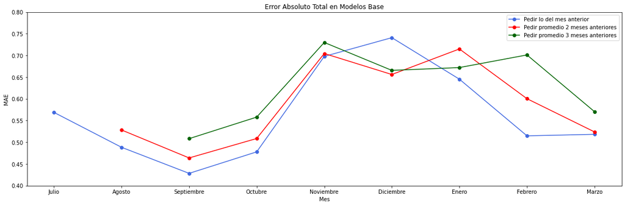

```python
ptl.figure(figsize=(20,6)) #Impresión de la figura
ptl.plot(mae.Mes, mae.mae_pedir_anterior,'-o',color="royalblue")
ptl.plot(mae.Mes, mae.mae_promedio_2_meses_anteriores, '-o', color="red")
ptl.plot(mae.Mes, mae.mae_promedio_3_meses_anteriores, '-o', color="darkgreen")
ptl.legend(['Pedir lo del mes anterior','Pedir promedio 2 meses anteriores','Pedir promedio 3 meses anteriores'])
ptl.ylim(0.4, .8)
ptl.ylabel('MAE')
ptl.xlabel('Mes')
ptl.title('Error Absoluto Total en Modelos Base')
```

## Resultados de desempeño que se obtuvieron a nivel general

Creemos que el mejor modelo a utilizar es el mae en el que se pronostica de acuerdo a las ventas del periodo anterior ya que tiene el menor error promedio en todos los meses salvo Diciembre, pero, si se evalúan los 9 meses en conjunto, sí nos conviene la utilización de este método.